# Lab 1: Understanding Regression Output

MATH 4780 / MSSC 5780 Regression Analysis

Author

Mehdi Maadooliat

**NoteCourse data**

This lab uses objects in `regression_datasets.rda`. Put the `.qmd` file and `regression_datasets.rda` in the same folder before rendering or working through the lab.

## Learning goals

By the end of this lab, you should be able to connect the output from `lm()` and `summary()` to the quantities developed in simple linear regression: least-squares estimates, residual variation, (R^2), coefficient tests, and the ANOVA decomposition.

We use the **rocket propellant** data from the earlier course slides. The response is propellant **strength**, and the explanatory variable is propellant **age**.

```r
library(ggplot2)
library(broom)

rocket_propellant
```

```
   strength   age
1      2159 15.50
2      1678 23.75
3      2316  8.00
4      2061 17.00
5      2208  5.50
6      1708 19.00
7      1785 24.00
8      2575  2.50
9      2358  7.50
10     2257 11.00
11     2165 13.00
12     2400  3.75
13     1780 25.00
14     2337  9.75
15     1765 22.00
16     2054 18.00
17     2414  6.00
18     2200 12.50
19     2654  2.00
20     1754 21.50
```

## 1. Explore the relationship

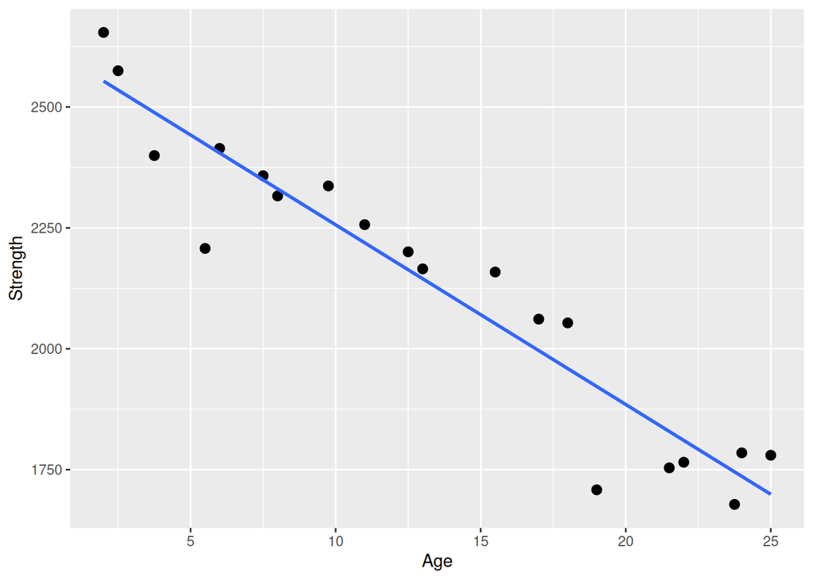

```r
ggplot(rocket_propellant, aes(x = age, y = strength)) +
  geom_point(size = 2.5) +
  geom_smooth(method = "lm", se = FALSE) +
  labs(x = "Age", y = "Strength")
```

1. Describe the direction, form, and strength of the relationship.
2. Are there any observations that look unusual?

## 2. Fit the model

```r
fit <- lm(strength ~ age, data = rocket_propellant)
summary(fit)
```

```
Call:
lm(formula = strength ~ age, data = rocket_propellant)

Residuals:
   Min     1Q Median     3Q    Max
-216.0  -50.7   28.7   66.6  106.8

Coefficients:
            Estimate Std. Error t value Pr(>|t|)
(Intercept)  2627.82      44.18    59.5  < 2e-16 ***
age           -37.15       2.89   -12.9  1.6e-10 ***
---
Signif. codes:  0 '***' 0.001 '**' 0.01 '*' 0.05 '.' 0.1 ' ' 1

Residual standard error: 96.1 on 18 degrees of freedom
Multiple R-squared:  0.902, Adjusted R-squared:  0.896
F-statistic:  165 on 1 and 18 DF,  p-value: 1.64e-10
```

Interpret the estimated intercept and slope in context. Is the intercept scientifically meaningful over the observed range of the data?

## 3. Reconstruct the least-squares estimates

Let (x_i) denote age and (y_i) denote strength. Compute

```r
x <- rocket_propellant$age
y <- rocket_propellant$strength

xbar <- mean(x)
ybar <- mean(y)
Sxx <- sum((x - xbar)^2)
Sxy <- sum((x - xbar) * (y - ybar))

b1 <- Sxy / Sxx
b0 <- ybar - b1 * xbar

c(intercept = b0, slope = b1)
```

```
intercept     slope
   2627.8     -37.2
```

```r
coef(fit)
```

```
(Intercept)         age
     2627.8       -37.2
```

Verify that your calculations agree with `coef(fit)`.

## 4. Sums of squares and (R^2)

```r
yhat <- fitted(fit)
e <- resid(fit)

SSE <- sum(e^2)
SST <- sum((y - ybar)^2)
SSR <- sum((yhat - ybar)^2)

c(SST = SST, SSR = SSR, SSE = SSE, check = SST - SSR - SSE)
```

```
     SST      SSR      SSE    check
1.69e+06 1.53e+06 1.66e+05 2.04e-10
```

```r
R2 <- SSR / SST
R2
```

```
[1] 0.902
```

```r
summary(fit)$r.squared
```

```
[1] 0.902
```

Interpret (R^2) in the context of propellant strength and age.

## 5. Test the slope

For simple linear regression,

```r
n <- nrow(rocket_propellant)
s <- sqrt(SSE / (n - 2))
se_b1 <- s / sqrt(Sxx)
t_b1 <- b1 / se_b1
p_b1 <- 2 * pt(-abs(t_b1), df = n - 2)

c(s = s, SE_slope = se_b1, t = t_b1, p_value = p_b1)
```

```
        s  SE_slope         t   p_value
 9.61e+01  2.89e+00 -1.29e+01  1.64e-10
```

```r
broom::tidy(fit, conf.int = TRUE)
```

```
# A tibble: 2 × 7
  term        estimate std.error statistic  p.value conf.low conf.high
  <chr>          <dbl>     <dbl>     <dbl>    <dbl>    <dbl>     <dbl>
1 (Intercept)   2628.      44.2       59.5 4.06e-22   2535.     2721.
2 age            -37.2      2.89     -12.9 1.64e-10    -43.2     -31.1
```

State the null and alternative hypotheses for the slope test and give a conclusion in context.

## 6. ANOVA table

```r
anova(fit)
```

```
Analysis of Variance Table

Response: strength
          Df  Sum Sq Mean Sq F value  Pr(>F)
age        1 1527483 1527483     165 1.6e-10 ***
Residuals 18  166255    9236
---
Signif. codes:  0 '***' 0.001 '**' 0.01 '*' 0.05 '.' 0.1 ' ' 1
```

For a simple linear regression, compare the (F)-statistic in the ANOVA table with the squared (t)-statistic for the slope. What do you notice?

## 7. Prediction

```r
predict(fit,
        newdata = data.frame(age = c(5, 10, 15)),
        interval = "prediction",
        level = 0.95)
```

```
   fit  lwr  upr
1 2442 2229 2655
2 2256 2048 2464
3 2071 1863 2278
```

Explain the difference between a confidence interval for the mean response and a prediction interval for a new observation.

## Takeaway

R output is not a separate procedure from the formulas: it is a compact summary of the same least-squares calculations, uncertainty estimates, and ANOVA decomposition developed in class.